# Reproducible Research with R and RStudio

March 16, 2015

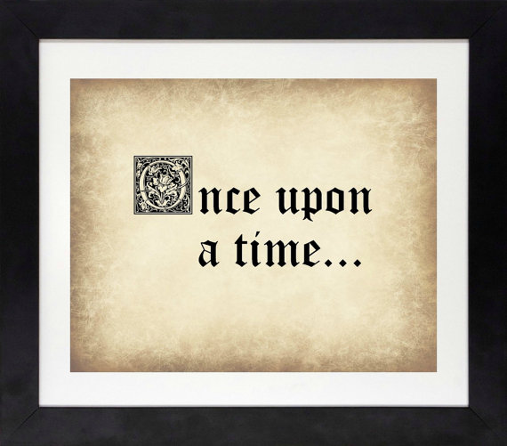

## Seven years ago …

- Phone call from brilliant, if somewhat frenetic friend and colleague
- Can you help me with a regression analysis?
- Lunch at Panera Bread with two laptops, a USB stick and breadsticks
- A few pleasant hours that evening noodling with an R script, later implemented in SAS
- Manuscript submitted to a high impact journal…
- Rejected!
- Submitted to an somewhat lower impact journal…
- Rejected!!
- Submitted to a low impact journal…
- Rejected!!!

## Several months ago …

- Submitted to a journal I'd never heard of…
- 53 emails, reams of SAS output, multiple MS Word files

## Two weeks ago

- Revise and reconsider!!!!
- "laceartion.manuscript.reveision.WJEM.revisonpercomments.march2105.inclyuding acuity model.docx"
- **Can you just edit the methods and results section?**
- Do you remember why we didn't include *covariate X6* in the model?
- They want the revised manuscript next week

## Old workflow

### SAS/Stata or R script –> MS Word

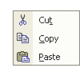

## Then, I learned to use a **TEXT** editor

### GNU Emacs developer – Richard Stallman

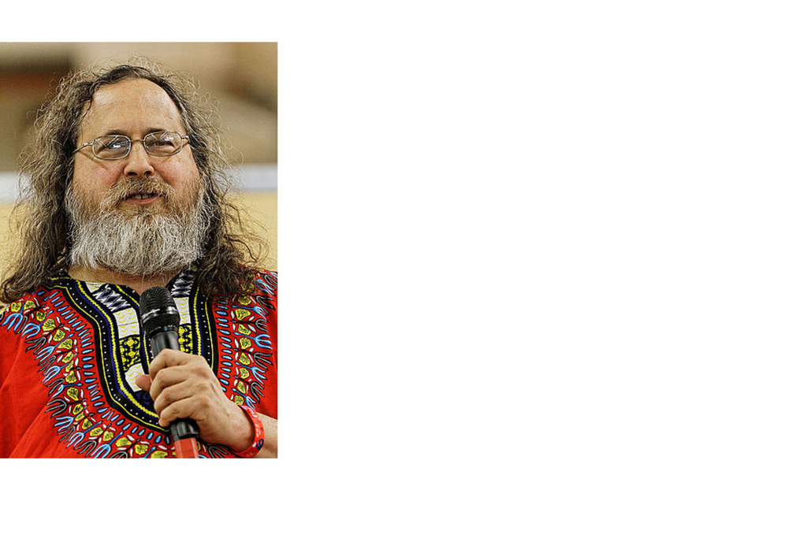

## Reproducible Research

- Given the raw data
  - and code used to analyse the data
  - and code used to generate figures, combined with
  - text describing methods and interpreting results
- someone else (or **future you**) can reproduce your analysis

## Literate Programming

### integrate plain text and code

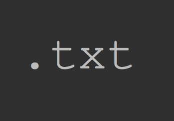

- [Why Geeks Love Plain Text (And Why You Should Too)](http://www.lifehack.org/articles/technology/why-geeks-love-plain-text-and-why-you-should-too.html)

## 2011 Master's Thesis

### Emacs/ESS/Sweave/LaTeX/pdf

[figure not shown]

## 2015 – RStudio IDE

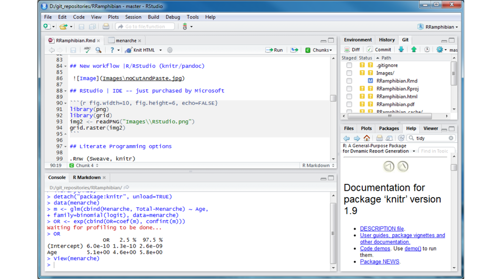

## Literate Programming options

- Sweave and knitr use a special text file with extension R `.Rnw`
  - `R` code chunks are started with `<< >>=` and ended with `@`
  - A `LaTeX` document that includes `R` code
  - Inline code is written `\Sexpr{ }`
  - Output(using Sweave or knitr) to produce pdf
- Rmarkdown (.Rmd)
  - `R` code chunks (and now other code 'engines' including SAS, python, awk)
  - `LaTeX` or `(r)markdown`
  - "knit" (using `knitr`), then output (using `pandoc`) to multiple possible formats
    - pdf, web pages, html slides, even MSWord

## Chunks

### .Rnw (R + Latex)

```
\documentclass{article}
\begin{document}

<<>>=
2+2
@

\end{document}
```

## Chunks

### .Rmd (R + rmarkdown)

The chunk below does arithmetic in **R** and prints the result.

````
```{r }
2+2
```
````

```
## [1] 4
```

## Inline R output

The sum of 2 + 2 is `` `r 2+2` ``

after 'knitting', produces:

The sum of 2 + 2 is 4.

## Chunk options

### Cache time consuming calculations

```r
pi_1000 <- pscl::simpi(1000)
pi_1000
```

```
## [1] 3.2
```

````
```{r , cache=TRUE}
pi_M <- pscl::simpi(100000000)
```
````

A better estimate for \(\pi\) is 3.1417

## Equations in R Markdown

- `LaTeX` Inline Equations – flanking $

```
The Arithmetic mean is equal to $\frac{1}{n} \sum_{i=i}^{n} x_{i}$,
or the summation of n numbers devided by n.
```

The Arithmetic mean is equal to \(\frac{1}{n} \sum_{i=i}^{n} x_{i}\), or the summation of n numbers devided by n.

- `LaTeX` Display Equations – flanking $$

\[ \begin{aligned} \dot{x} & = \sigma(y-x) \\ \dot{y} & = \rho x - y = xz \\ \dot{z} & = -\beta z + xy \end{aligned} \]

## No Fret Figures

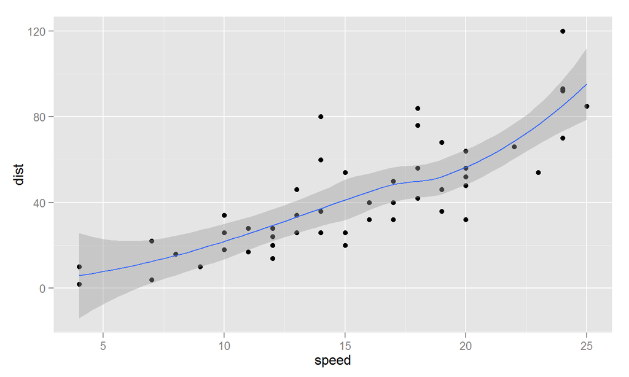

```r
library(ggplot2)
qplot(speed, dist, data=cars) + geom_smooth()
```

## Simple Tables

```r
knitr::kable(mtcars[1:5,])
```

|  | mpg | cyl | disp | hp | drat | wt | qsec | vs | am | gear | carb |
| --- | --- | --- | --- | --- | --- | --- | --- | --- | --- | --- | --- |
| Mazda RX4 | 21.0 | 6 | 160 | 110 | 3.90 | 2.620 | 16.46 | 0 | 1 | 4 | 4 |
| Mazda RX4 Wag | 21.0 | 6 | 160 | 110 | 3.90 | 2.875 | 17.02 | 0 | 1 | 4 | 4 |
| Datsun 710 | 22.8 | 4 | 108 | 93 | 3.85 | 2.320 | 18.61 | 1 | 1 | 4 | 1 |
| Hornet 4 Drive | 21.4 | 6 | 258 | 110 | 3.08 | 3.215 | 19.44 | 1 | 0 | 3 | 1 |
| Hornet Sportabout | 18.7 | 8 | 360 | 175 | 3.15 | 3.440 | 17.02 | 0 | 0 | 3 | 2 |

## Model Summary Tables

Print pretty summary tables by extracting model components and converting to a matrix

```r
data(menarche)
m <- glm(cbind(Menarche, Total-Menarche) ~ Age,
         family=binomial(logit), data=menarche)

OR <- exp(cbind(OR=coef(m), confint(m)))
kable(OR)
```

|  | OR | 2.5 % | 97.5 % |
| --- | --- | --- | --- |
| (Intercept) | 0.000 | 0.000 | 0.000 |
| Age | 5.114 | 4.573 | 5.762 |

## Beautiful model tables using `texreg`

```r
htmlreg(m, caption="Age at Menarche", caption.above=TRUE,
        inline.css = TRUE, doctype = TRUE, html.tag = TRUE,
        head.tag = TRUE, body.tag = TRUE, ci.force=TRUE,
        ci.test=NULL,bold=TRUE)
```

Age at Menarche

|  | **Model 1** |
| --- | --- |
| (Intercept) | **-21.23** |
|  | [-22.74; -19.72] |
| Age | **1.63** |
|  | [1.52; 1.75] |
| AIC | 114.76 |
| BIC | 117.19 |
| Log Likelihood | -55.38 |
| Deviance | 26.70 |
| Num. obs. | 25 |

## Version control

My github page for this talk

[figure not shown]

## Why Use git/github?

- Provides secure backup
- Tracks the history of all changes to every file
- Facilitates working on multiple computers
- Allows frequent "snapshots" (`commits`) of code
- Great for collaboration

## Conclusions

- Use RStudio (incorporates a good text editor)
- Quick and Dirty analysis labnotes
  - Write in rmarkdown, convert to html
- Serious work (thesis, book, manuscripts)
  - Write in Rnw, LaTeX, convert to pdf
  - Try [Lyx](http://www.lyx.org/)
- For students/trainees – demand reproducible homework/analysis notebooks
- Use distributive version control
  - [git](http://git-scm.com)
  - [Github](https://github.com)

## Challenges

- Colleagues/collaborators/journals use Microsoft Word
- Opensource: not supported amazing support
  - Must be willing to post [reproducible examples](http://stackoverflow.com/questions/5963269/how-to-make-a-great-r-reproducible-example)
- However, relies on a complex, rapidly changing toolchain
  - (knitr, rmarkdown, markdown,[pandoc](http://johnmacfarlane.net/pandoc/))

## Reproducible today

### Still reproducible in 5 years?

```r
head(devtools::session_info()$packages)
```

```
##  package    * version date       source
##  colorspace * 1.2-6   2015-03-11 CRAN (R 3.1.3)
##  devtools   * 1.7.0   2015-01-17 CRAN (R 3.1.2)
##  digest     * 0.6.8   2014-12-31 CRAN (R 3.1.2)
##  evaluate   * 0.5.5   2014-04-29 CRAN (R 3.1.0)
##  formatR    * 1.0     2014-08-25 CRAN (R 3.1.1)
##  ggplot2      1.0.0   2014-05-21 CRAN (R 3.1.0)
```

## Future Proofing

- Language engines (julia, python, sas)
- [Packrat: Reproducible package management for R](http://rstudio.github.io/packrat/)
- Virtual Machines (on the cloud)

## My Favorite Books and Web Resources

[Reproducible Research with R and R Studio](http://www.crcpress.com/product/isbn/9781466572843)

[Tools for Reproducible Research and Dynamic Documents with R](http://www.stat.tamu.edu/~mmclean/iamcs2/#1)

[initial steps toward reproducible research](http://kbroman.org/steps2rr/)

[Reproducible Research (part of the Johns Hopkins data science specialization at Coursera)](https://www.coursera.org/course/repdata)

[Dynamic Documents with R and Knitr](http://www.crcpress.com/product/isbn/9781482203530) – [Xihui Xie](http://yihui.name/knitr/)

[knitr in a knutshell](http://kbroman.org/knitr_knutshell/)

[RStudio](http://www.rstudio.com/products/rstudio/)

[R packages: Git and GitHub by Hadley Wickham](http://r-pkgs.had.co.nz/git.html)